# EasyVisa_Project

## Boosting - Model Building and Hyperparameter Tuning

### AdaBoost Classifier

```python
ab_classifier = AdaBoostClassifier(random_state=1)
ab_classifier.fit(X_train,y_train)
```

```
AdaBoostClassifier(random_state=1)
```

#### Checking model performance on training set

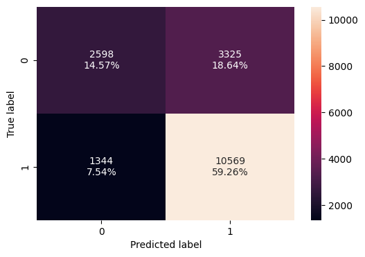

```python
confusion_matrix_sklearn(ab_classifier,X_train,y_train)
```

```python
ab_classifier_model_train_perf = model_performance_classification_sklearn(ab_classifier,X_train,y_train)
ab_classifier_model_train_perf
```

|  | Accuracy | Recall | Precision | F1 |
| --- | --- | --- | --- | --- |
| 0 | 0.738226 | 0.887182 | 0.760688 | 0.81908 |

#### Checking model performance on test set

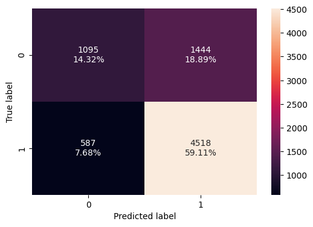

```python
confusion_matrix_sklearn(ab_classifier,X_test,y_test)
```

```python
ab_classifier_model_test_perf = model_performance_classification_sklearn(ab_classifier,X_test,y_test)
ab_classifier_model_test_perf
```

|  | Accuracy | Recall | Precision | F1 |
| --- | --- | --- | --- | --- |
| 0 | 0.734301 | 0.885015 | 0.757799 | 0.816481 |

In contrast to the decision tree, random forest, and bagging classifier, the AdaBoost classifier demonstrates no signs of overfitting the training data. It exhibits a consistent and generalized performance on both the training and testing data, achieving an F1 score of 0.819 and 0.816, respectively.

### Hyperparameter Tuning - AdaBoost Classifier

```python
# Choose the type of classifier.
abc_tuned = AdaBoostClassifier(random_state=1)

# Grid of parameters to choose from
parameters = {
    # Let's try different max_depth for base_estimator
    "base_estimator": [
        DecisionTreeClassifier(max_depth=1, class_weight="balanced", random_state=1),
        DecisionTreeClassifier(max_depth=2, class_weight="balanced", random_state=1),
    ],
    "n_estimators": np.arange(80, 101, 10),
    "learning_rate": np.arange(0.1, 0.4, 0.1),
}

# Type of scoring used to compare parameter  combinations
acc_scorer = metrics.make_scorer(metrics.f1_score)

# Run the grid search
grid_obj = GridSearchCV(abc_tuned, parameters, scoring=scorer,cv=5)
grid_obj = grid_obj.fit(X_train, y_train)

# Set the clf to the best combination of parameters
abc_tuned = grid_obj.best_estimator_

# Fit the best algorithm to the data.
abc_tuned.fit(X_train, y_train)
```

```
AdaBoostClassifier(base_estimator=DecisionTreeClassifier(class_weight='balanced',
                                                         max_depth=1,
                                                         random_state=1),
                   learning_rate=0.1, n_estimators=100, random_state=1)
```

#### Checking model performance on training set

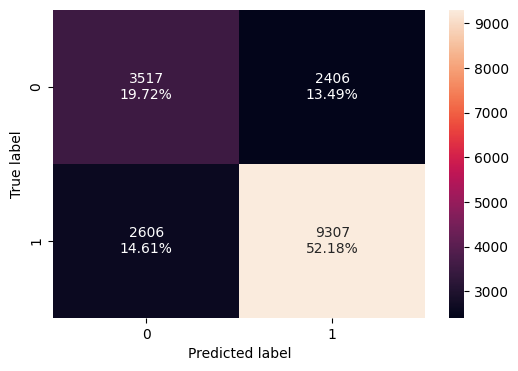

```python
confusion_matrix_sklearn(abc_tuned,X_train,y_train)
```

```python
abc_tuned_model_train_perf = model_performance_classification_sklearn(abc_tuned,X_train,y_train)
abc_tuned_model_train_perf
```

|  | Accuracy | Recall | Precision | F1 |
| --- | --- | --- | --- | --- |
| 0 | 0.718995 | 0.781247 | 0.794587 | 0.787861 |

#### Checking model performance on test set

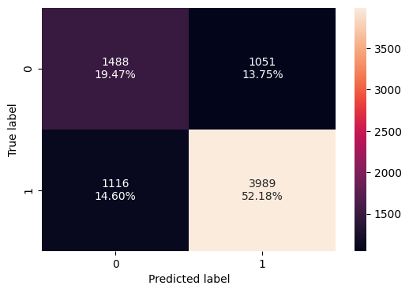

```python
confusion_matrix_sklearn(abc_tuned,X_test,y_test)
```

```python
abc_tuned_model_test_perf = model_performance_classification_sklearn(abc_tuned,X_test,y_test)
abc_tuned_model_test_perf
```

|  | Accuracy | Recall | Precision | F1 |
| --- | --- | --- | --- | --- |
| 0 | 0.71651 | 0.781391 | 0.791468 | 0.786397 |

The model that underwent hyperparameter tuning is delivering comparable performance to the default AdaBoost model.

### Gradient Boosting Classifier

```python
gb_classifier = GradientBoostingClassifier(random_state=1)
gb_classifier.fit(X_train,y_train)
```

```
GradientBoostingClassifier(random_state=1)
```

#### Checking model performance on training set

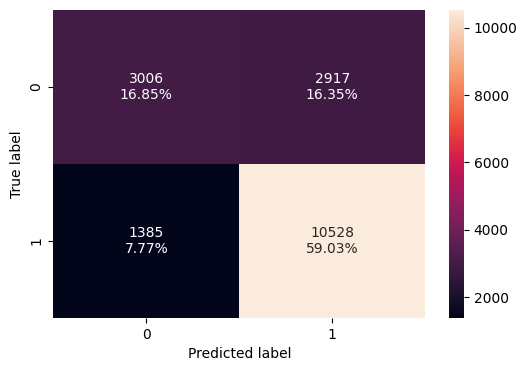

```python
confusion_matrix_sklearn(gb_classifier,X_train,y_train)
```

```python
gb_classifier_model_train_perf = model_performance_classification_sklearn(gb_classifier,X_train,y_train)
gb_classifier_model_train_perf
```

|  | Accuracy | Recall | Precision | F1 |
| --- | --- | --- | --- | --- |
| 0 | 0.758802 | 0.88374 | 0.783042 | 0.830349 |

#### Checking model performance on test set

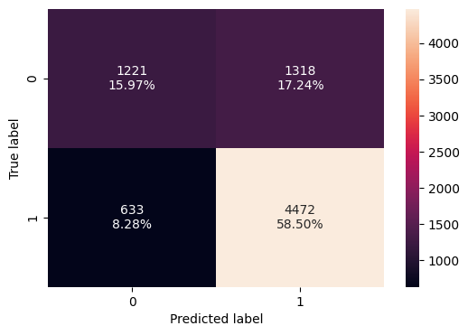

```python
confusion_matrix_sklearn(gb_classifier,X_test,y_test)
```

```python
gb_classifier_model_test_perf = model_performance_classification_sklearn(gb_classifier,X_test,y_test)
gb_classifier_model_test_perf
```

|  | Accuracy | Recall | Precision | F1 |
| --- | --- | --- | --- | --- |
| 0 | 0.744767 | 0.876004 | 0.772366 | 0.820927 |

The gradient boosting model demonstrates a generalized performance on both the training and testing data, achieving exceptionally high F1 scores of 0.830 and 0.821, respectively.

### Hyperparameter Tuning - Gradient Boosting Classifier

```python
# Choose the type of classifier.
gbc_tuned = GradientBoostingClassifier(
    init=AdaBoostClassifier(random_state=1), random_state=1
)

# Grid of parameters to choose from
parameters = {
    "n_estimators": [200, 250],
    "subsample": [0.9, 1],
    "max_features": [0.8, 0.9],
    "learning_rate": np.arange(0.1, 0.21, 0.1),
}

# Type of scoring used to compare parameter combinations
acc_scorer = metrics.make_scorer(metrics.f1_score)

# Run the grid search
grid_obj = GridSearchCV(gbc_tuned, parameters, scoring=scorer,cv=5)
grid_obj = grid_obj.fit(X_train, y_train)

# Set the clf to the best combination of parameters
gbc_tuned = grid_obj.best_estimator_

# Fit the best algorithm to the data.
gbc_tuned.fit(X_train, y_train)
```

```
GradientBoostingClassifier(init=AdaBoostClassifier(random_state=1),
                           max_features=0.8, n_estimators=200, random_state=1,
                           subsample=1)
```

#### Checking model performance on training set

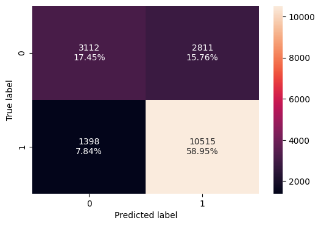

```python
confusion_matrix_sklearn(gbc_tuned,X_train,y_train)
```

```python
gbc_tuned_model_train_perf = model_performance_classification_sklearn(gbc_tuned,X_train,y_train)
gbc_tuned_model_train_perf
```

|  | Accuracy | Recall | Precision | F1 |
| --- | --- | --- | --- | --- |
| 0 | 0.764017 | 0.882649 | 0.789059 | 0.833234 |

#### Checking model performance on test set

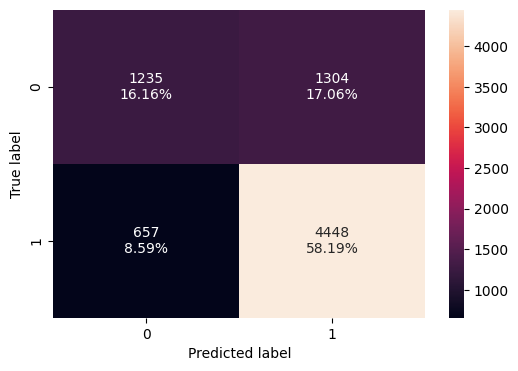

```python
confusion_matrix_sklearn(gbc_tuned,X_test,y_test)
```

```python
gbc_tuned_model_test_perf = model_performance_classification_sklearn(gbc_tuned,X_test,y_test)
gbc_tuned_model_test_perf
```

|  | Accuracy | Recall | Precision | F1 |
| --- | --- | --- | --- | --- |
| 0 | 0.743459 | 0.871303 | 0.773296 | 0.819379 |

The gradient boost classifier model is pretty similar before and after hyperparameter tuning.

### XGBoost Classifier

```python
xgb_classifier = XGBClassifier(random_state=1, eval_metric='logloss')
xgb_classifier.fit(X_train,y_train)
```

```
XGBClassifier(base_score=None, booster=None, callbacks=None,
              colsample_bylevel=None, colsample_bynode=None,
              colsample_bytree=None, early_stopping_rounds=None,
              enable_categorical=False, eval_metric='logloss',
              feature_types=None, gamma=None, gpu_id=None, grow_policy=None,
              importance_type=None, interaction_constraints=None,
              learning_rate=None, max_bin=None, max_cat_threshold=None,
              max_cat_to_onehot=None, max_delta_step=None, max_depth=None,
              max_leaves=None, min_child_weight=None, missing=nan,
              monotone_constraints=None, n_estimators=100, n_jobs=None,
              num_parallel_tree=None, predictor=None, random_state=1, ...)
```

#### Checking model performance on training set

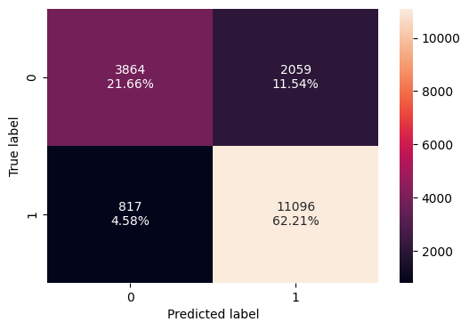

```python
confusion_matrix_sklearn(xgb_classifier,X_train,y_train)
```

```python
xgb_classifier_model_train_perf = model_performance_classification_sklearn(xgb_classifier,X_train,y_train)
xgb_classifier_model_train_perf
```

|  | Accuracy | Recall | Precision | F1 |
| --- | --- | --- | --- | --- |
| 0 | 0.838753 | 0.931419 | 0.843482 | 0.885272 |

#### Checking model performance on test set

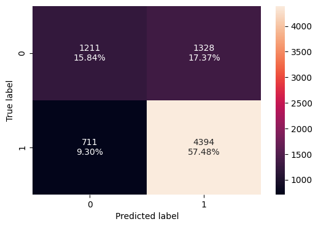

```python
confusion_matrix_sklearn(xgb_classifier,X_test,y_test)
```

```python
xgb_classifier_model_test_perf = model_performance_classification_sklearn(xgb_classifier,X_test,y_test)
xgb_classifier_model_test_perf
```

|  | Accuracy | Recall | Precision | F1 |
| --- | --- | --- | --- | --- |
| 0 | 0.733255 | 0.860725 | 0.767913 | 0.811675 |

The XGBoost classifier model is overfitting the training data.

### Hyperparameter Tuning - XGBoost Classifier

```python
# Choose the type of classifier.
xgb_tuned = XGBClassifier(random_state=1, eval_metric="logloss")

# Grid of parameters to choose from
parameters = {
    "n_estimators": np.arange(150, 250, 50),
    "scale_pos_weight": [1, 2],
    "subsample": [0.9, 1],
    "learning_rate": np.arange(0.1, 0.21, 0.1),
    "gamma": [3, 5],
    "colsample_bytree": [0.8, 0.9],
    "colsample_bylevel": [ 0.9, 1],
}

# Type of scoring used to compare parameter combinations
acc_scorer = metrics.make_scorer(metrics.f1_score)

# Run the grid search
grid_obj = GridSearchCV(xgb_tuned, parameters,scoring=scorer,cv=5)
grid_obj = grid_obj.fit(X_train, y_train)

# Set the clf to the best combination of parameters
xgb_tuned = grid_obj.best_estimator_

# Fit the best algorithm to the data.
xgb_tuned.fit(X_train, y_train)
```

```
XGBClassifier(base_score=None, booster=None, callbacks=None,
              colsample_bylevel=0.9, colsample_bynode=None,
              colsample_bytree=0.9, early_stopping_rounds=None,
              enable_categorical=False, eval_metric='logloss',
              feature_types=None, gamma=5, gpu_id=None, grow_policy=None,
              importance_type=None, interaction_constraints=None,
              learning_rate=0.1, max_bin=None, max_cat_threshold=None,
              max_cat_to_onehot=None, max_delta_step=None, max_depth=None,
              max_leaves=None, min_child_weight=None, missing=nan,
              monotone_constraints=None, n_estimators=150, n_jobs=None,
              num_parallel_tree=None, predictor=None, random_state=1, ...)
```

#### Checking model performance on training set

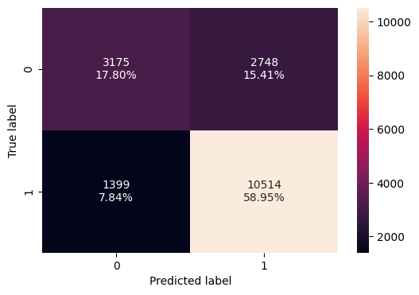

```python
confusion_matrix_sklearn(xgb_tuned,X_train,y_train)
```

```python
xgb_tuned_model_train_perf = model_performance_classification_sklearn(xgb_tuned,X_train,y_train)
xgb_tuned_model_train_perf
```

|  | Accuracy | Recall | Precision | F1 |
| --- | --- | --- | --- | --- |
| 0 | 0.767493 | 0.882565 | 0.792791 | 0.835273 |

#### Checking model performance on test set

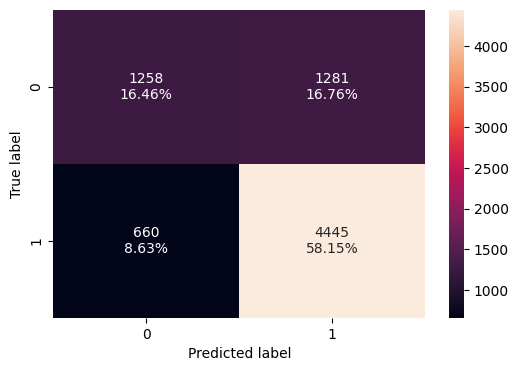

```python
confusion_matrix_sklearn(xgb_tuned,X_test,y_test)
```

```python
xgb_tuned_model_test_perf = model_performance_classification_sklearn(xgb_tuned,X_test,y_test)
xgb_tuned_model_test_perf
```

|  | Accuracy | Recall | Precision | F1 |
| --- | --- | --- | --- | --- |
| 0 | 0.746075 | 0.870715 | 0.776284 | 0.820792 |

The overfitting has been mitigated, resulting in a model that exhibits generalized performance on both the training and testing data. The F1 scores for the training and testing datasets are notably high, measuring 0.835 and 0.821, respectively.

## Stacking Classifier

```python
estimators = [
    ("AdaBoost", ab_classifier),
    ("Gradient Boosting", gbc_tuned),
    ("Random Forest", rf_tuned),
]

final_estimator = xgb_tuned

stacking_classifier = StackingClassifier(estimators=estimators,final_estimator=final_estimator)

stacking_classifier.fit(X_train,y_train)
```

```
StackingClassifier(estimators=[('AdaBoost', AdaBoostClassifier(random_state=1)),
                               ('Gradient Boosting',
                                GradientBoostingClassifier(init=AdaBoostClassifier(random_state=1),
                                                           max_features=0.8,
                                                           n_estimators=200,
                                                           random_state=1,
                                                           subsample=1)),
                               ('Random Forest',
                                RandomForestClassifier(max_depth=10,
                                                       min_samples_split=7,
                                                       n_estimators=20,
                                                       oob_score=True,
                                                       random_state=1))],...
                                                 gpu_id=None, grow_policy=None,
                                                 importance_type=None,
                                                 interaction_constraints=None,
                                                 learning_rate=0.1,
                                                 max_bin=None,
                                                 max_cat_threshold=None,
                                                 max_cat_to_onehot=None,
                                                 max_delta_step=None,
                                                 max_depth=None,
                                                 max_leaves=None,
                                                 min_child_weight=None,
                                                 missing=nan,
                                                 monotone_constraints=None,
                                                 n_estimators=150, n_jobs=None,
                                                 num_parallel_tree=None,
                                                 predictor=None, random_state=1, ...))
```

### Checking model performance on training set

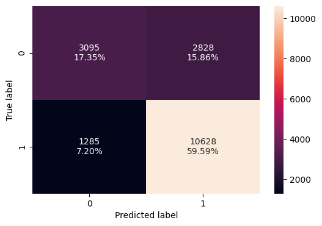

```python
confusion_matrix_sklearn(stacking_classifier,X_train,y_train)
```

```python
stacking_classifier_model_train_perf = model_performance_classification_sklearn(stacking_classifier,X_train,y_train)
stacking_classifier_model_train_perf
```

|  | Accuracy | Recall | Precision | F1 |
| --- | --- | --- | --- | --- |
| 0 | 0.769399 | 0.892135 | 0.789834 | 0.837873 |

### Checking model performance on test set

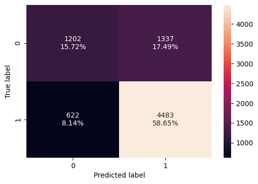

```python
confusion_matrix_sklearn(stacking_classifier,X_test,y_test)
```

```python
stacking_classifier_model_test_perf = model_performance_classification_sklearn(stacking_classifier,X_test,y_test)
stacking_classifier_model_test_perf
```

|  | Accuracy | Recall | Precision | F1 |
| --- | --- | --- | --- | --- |
| 0 | 0.743721 | 0.878159 | 0.770275 | 0.820686 |

The stacking classifier is slightly overfitting the data, similar to the other models after hyperparameter tuining. The F1 scores for the training set and testing set are 0.838 and 0.821, respectively

## Model Performance Comparison and Final Model Selection

```python
# training performance comparison

models_train_comp_df = pd.concat(
    [
        decision_tree_perf_train.T,
        dtree_estimator_model_train_perf.T,
        bagging_classifier_model_train_perf.T,
        bagging_estimator_tuned_model_train_perf.T,
        rf_estimator_model_train_perf.T,
        rf_tuned_model_train_perf.T,
        ab_classifier_model_train_perf.T,
        abc_tuned_model_train_perf.T,
        gb_classifier_model_train_perf.T,
        gbc_tuned_model_train_perf.T,
        xgb_classifier_model_train_perf.T,
        xgb_tuned_model_train_perf.T,
        stacking_classifier_model_train_perf.T,
    ],
    axis=1,
)
models_train_comp_df.columns = [
    "Decision Tree",
    "Tuned Decision Tree",
    "Bagging Classifier",
    "Tuned Bagging Classifier",
    "Random Forest",
    "Tuned Random Forest",
    "Adaboost Classifier",
    "Tuned Adaboost Classifier",
    "Gradient Boost Classifier",
    "Tuned Gradient Boost Classifier",
    "XGBoost Classifier",
    "XGBoost Classifier Tuned",
    "Stacking Classifier",
]
print("Training performance comparison:")
models_train_comp_df
```

```
Training performance comparison:
```

|  | Decision Tree | Tuned Decision Tree | Bagging Classifier | Tuned Bagging Classifier | Random Forest | Tuned Random Forest | Adaboost Classifier | Tuned Adaboost Classifier | Gradient Boost Classifier | Tuned Gradient Boost Classifier | XGBoost Classifier | XGBoost Classifier Tuned | Stacking Classifier |
| --- | --- | --- | --- | --- | --- | --- | --- | --- | --- | --- | --- | --- | --- |
| Accuracy | 1.0 | 0.712548 | 0.985198 | 0.996187 | 1.0 | 0.769119 | 0.738226 | 0.718995 | 0.758802 | 0.764017 | 0.838753 | 0.767493 | 0.769399 |
| Recall | 1.0 | 0.931923 | 0.985982 | 0.999916 | 1.0 | 0.918660 | 0.887182 | 0.781247 | 0.883740 | 0.882649 | 0.931419 | 0.882565 | 0.892135 |
| Precision | 1.0 | 0.720067 | 0.991810 | 0.994407 | 1.0 | 0.776556 | 0.760688 | 0.794587 | 0.783042 | 0.789059 | 0.843482 | 0.792791 | 0.789834 |
| F1 | 1.0 | 0.812411 | 0.988887 | 0.997154 | 1.0 | 0.841652 | 0.819080 | 0.787861 | 0.830349 | 0.833234 | 0.885272 | 0.835273 | 0.837873 |

```python
# testing performance comparison

models_test_comp_df = pd.concat(
    [
        decision_tree_perf_test.T,
        dtree_estimator_model_test_perf.T,
        rf_estimator_model_test_perf.T,
        rf_tuned_model_test_perf.T,
        bagging_classifier_model_test_perf.T,
        bagging_estimator_tuned_model_test_perf.T,
        ab_classifier_model_test_perf.T,
        abc_tuned_model_test_perf.T,
        gb_classifier_model_test_perf.T,
        gbc_tuned_model_test_perf.T,
        xgb_classifier_model_test_perf.T,
        xgb_tuned_model_test_perf.T,
        stacking_classifier_model_test_perf.T
    ],
    axis=1,
)
models_test_comp_df.columns = [
    "Decision Tree",
    "Decision Tree Tuned",
    "Random Forest",
    "Random Forest Tuned",
    "Bagging Classifier",
    "Bagging Estimator Tuned",
    "Adaboost Classifier",
    "Adabosst Classifier Tuned",
    "Gradient Boost Classifier",
    "Gradient Boost Classifier Tuned",
    "XGBoost Classifier",
    "XGBoost Classifier Tuned",
    "Stacking Classifier"]
print("Testing performance comparison:")
models_test_comp_df
```

```
Testing performance comparison:
```

|  | Decision Tree | Decision Tree Tuned | Random Forest | Random Forest Tuned | Bagging Classifier | Bagging Estimator Tuned | Adaboost Classifier | Adabosst Classifier Tuned | Gradient Boost Classifier | Gradient Boost Classifier Tuned | XGBoost Classifier | XGBoost Classifier Tuned | Stacking Classifier |
| --- | --- | --- | --- | --- | --- | --- | --- | --- | --- | --- | --- | --- | --- |
| Accuracy | 0.664835 | 0.706567 | 0.727368 | 0.738095 | 0.691523 | 0.724228 | 0.734301 | 0.716510 | 0.744767 | 0.743459 | 0.733255 | 0.746075 | 0.743721 |
| Recall | 0.742801 | 0.930852 | 0.847209 | 0.898923 | 0.764153 | 0.895397 | 0.885015 | 0.781391 | 0.876004 | 0.871303 | 0.860725 | 0.870715 | 0.878159 |
| Precision | 0.752232 | 0.715447 | 0.768343 | 0.755391 | 0.771711 | 0.743857 | 0.757799 | 0.791468 | 0.772366 | 0.773296 | 0.767913 | 0.776284 | 0.770275 |
| F1 | 0.747487 | 0.809058 | 0.805851 | 0.820930 | 0.767913 | 0.812622 | 0.816481 | 0.786397 | 0.820927 | 0.819379 | 0.811675 | 0.820792 | 0.820686 |

- The decision tree, random forest (default and tuned), and bagging classifier (default and tuned) were observed to exhibit overfitting tendencies on the training dataset.
- On the other hand, the tuned decision tree, Adaboost (default and tuned), gradient boost (default and tuned), and XGBoost (tuned) models showcased generalized performance on both the training and testing datasets.
- Among these models, Random Forest (Tuned), Gradient Boost (default), XGBoost (tuned), and the Stacking Classifier achieved the highest F1 score, although all models performed relatively similarly.

### Important features of the final model

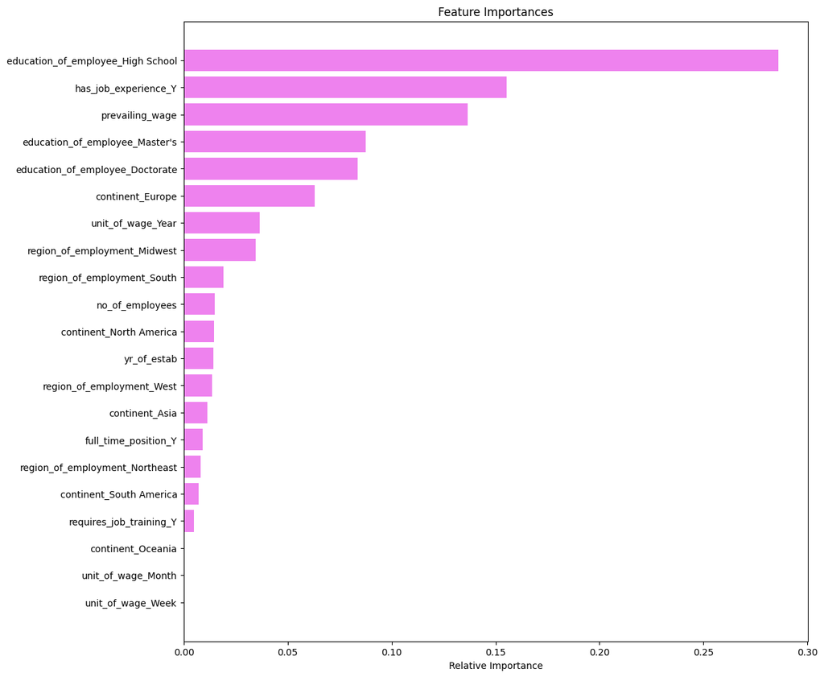

```python
feature_names = X_train.columns
importances = gb_classifier.feature_importances_
indices = np.argsort(importances)

plt.figure(figsize=(12, 12))
plt.title("Feature Importances")
plt.barh(range(len(indices)), importances[indices], color="violet", align="center")
plt.yticks(range(len(indices)), [feature_names[i] for i in indices])
plt.xlabel("Relative Importance")
plt.show()
```

The most important factors that go into determining if a Visa gets approved are the education of the employee, if an employee had prior job experience, and the average prevailing wage of the employee.

## Business Insights and Recommendations

### Businness Insights:

Regarding the Office of Foreign Labor Certification (OFLC), the following insights are noteworthy for pre-screening applicants to obtain a Visa:

1. Education Level: Applications for jobs that necessitate a high school diploma are highly likely to be denied. Conversely, applications for positions requiring a Master's degree or doctorate have a significantly higher chance of approval.
2. Prior Job Experience: Applicants lacking previous job experience are more prone to be denied compared to those with relevant experience in the field.
3. Prevailing Wage: Applications for jobs with higher prevailing wages have a greater likelihood of approval. This trend is particularly noticeable for positions with an hourly unit of wage.

These insights provide valuable guidance for the pre-screening process, helping to identify critical factors that influence the outcome of OFLC applications.

### Recommendations:

To optimize the allocation of limited resources in screening applications, the OFLC can consider the following approaches:

1. Education-Based Sorting: Sort applications based on the level of education, giving priority to those with higher educational qualifications for review.
2. Experience-Based Sorting: Sort applications based on the applicant's previous job experience, prioritizing those with relevant experience for review.
3. Wage-Based Sorting: Segment applications into two groups based on the wage type (hourly or annual) and sort each group based on the prevailing wage. Begin by reviewing applications for salaried positions from highest to lowest wage.

Comparison of Models: While the tuned Random Forest classifier has demonstrated the best performance among the models developed, the default Gradient Boost classifier performs only slightly worse in terms of the F1 score but the data is fit more properly.

Examining Decision-Making: It is crucial for the OFLC to thoroughly investigate why certification or denial can be predicted with such accuracy using only three nodes, as highlighted earlier. This analysis will help identify potential biases against applications for less skilled, entry-level, or hourly positions.

These insights can guide the OFLC in optimizing their screening process and ensuring fair and efficient decision-making.